# 21 - Meta analysis

Francisco E. Fonturbel

08/June/2026

## A meta-analysis example based on the effectiveness of biological control on crop pests

Today we will use some data of [Diaz-Siefer et al. 2022](https://link.springer.com/article/10.1007/s10340-021-01438-4) as a working example. This dataset contains data of crop damage made by pest insects under different agricultural managment scenarios.

```r
#Loading data file
data<-read.table("./data/21_data_meta_damage.txt", header = T)
attach(data)

#Loading packages required
library(meta)
```

## Overall effects

How important is biological control on crop damage?

Let’s see it using a random-effects model:

```r
overall.mod<-metacont(Ne, Xe, Se, Nc, Xc, Sc, data = data,
                      studlab = paste(caseID),
                      comb.fixed = FALSE,
                      comb.random = TRUE,
                      method.tau = "REML",
                      hakn = TRUE,
                      prediction = TRUE,
                      sm = "SMD",
                      method.smd = "Hedges")

summary(overall.mod)
```

```
##         SMD             95% CI %W(random)
## D01 -0.3457 [-1.0044;  0.3131]        2.0
## D02  0.6914 [ 0.0166;  1.3661]        2.0
## D03  0.1458 [-0.5085;  0.8000]        2.0
## D04  0.4355 [-0.5022;  1.3731]        1.5
## D05  0.5657 [-0.2899;  1.4213]        1.6
## D06  0.7060 [ 0.0652;  1.3467]        2.1
## D07 -0.4752 [-1.4731;  0.5227]        1.4
## D08  0.4065 [-0.5866;  1.3996]        1.4
## D09  0.2146 [-0.3307;  0.7599]        2.3
## D10  0.7336 [-0.3611;  1.8282]        1.3
## D11  0.1270 [-0.6741;  0.9281]        1.7
## D12  0.4391 [-0.2863;  1.1646]        1.9
## D13 -0.9234 [-1.6814; -0.1654]        1.8
## D14 -0.1591 [-0.8761;  0.5578]        1.9
## D15  1.5484 [ 0.0418;  3.0550]        0.8
## D16  0.8762 [-0.1021;  1.8544]        1.4
## D17  0.8850 [-0.4477;  2.2177]        1.0
## D18  1.8053 [ 0.7314;  2.8791]        1.3
## D19  1.8727 [ 1.1997;  2.5457]        2.0
## D20  0.7542 [ 0.1789;  1.3295]        2.2
## D21  0.1642 [-0.3912;  0.7195]        2.3
## D22  1.7740 [ 1.1122;  2.4358]        2.0
## D23  0.3502 [-0.3384;  1.0387]        2.0
## D24  1.0885 [ 0.3832;  1.7938]        1.9
## D25  0.5305 [-0.1355;  1.1965]        2.0
## D26  1.7491 [ 0.9687;  2.5294]        1.8
## D27  1.3660 [ 0.3149;  2.4172]        1.3
## D28  0.6875 [-0.3295;  1.7046]        1.4
## D29  0.6276 [ 0.2257;  1.0295]        2.6
## D30  0.7488 [-0.1647;  1.6623]        1.5
## D31  1.2187 [ 0.2473;  2.1902]        1.4
## D32  0.5088 [-0.3850;  1.4026]        1.6
## D33  0.5497 [-0.3469;  1.4464]        1.6
## D34  0.1643 [-0.7140;  1.0427]        1.6
## D35 -0.3764 [-1.2625;  0.5096]        1.6
## D36  0.8035 [-0.0340;  1.6411]        1.7
## D37  0.6286 [ 0.1094;  1.1478]        2.3
## D38 -0.5406 [-1.0564; -0.0248]        2.4
## D39  0.2939 [-0.1469;  0.7346]        2.5
```

[output cut: 27 more lines]

```
##  tau^2 = 0.2097 [0.1015; 0.3868]; tau = 0.4580 [0.3186; 0.6219]
##  I^2 = 61.0% [48.0%; 70.7%]; H = 1.60 [1.39; 1.85]
##
## Test of heterogeneity:
##       Q d.f.  p-value
##  143.53   56 < 0.0001
##
## Details of meta-analysis methods:
## - Inverse variance method
## - Restricted maximum-likelihood estimator for tau^2
## - Q-Profile method for confidence interval of tau^2 and tau
## - Calculation of I^2 based on Q
## - Hartung-Knapp adjustment for random effects model (df = 56)
## - Prediction interval based on t-distribution (df = 56)
## - Hedges' g (bias corrected standardised mean difference; using exact formulae)
```

```r
#forest(overall.mod,
#            comb.random = TRUE)
```

Great! biological control has a **significant overall effect** on crop damage. Also, there is a **significant heterogeneity** in the model (which is expected in this kind of models)

#### (1) Funnel plot

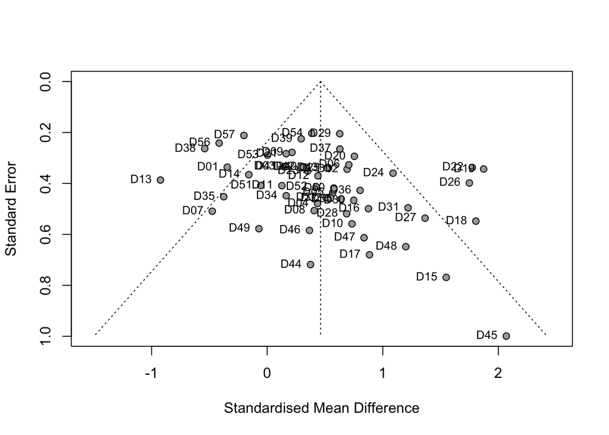

```r
funnel(overall.mod, studlab = TRUE)
```

Is there a significant bias on this? let’s test it;

```r
metabias(overall.mod)
```

```
## Linear regression test of funnel plot asymmetry
##
## Test result: t = 2.48, df = 55, p-value = 0.0162
## Bias estimate: 1.5849 (SE = 0.6390)
##
## Details:
## - multiplicative residual heterogeneity variance (tau^2 = 2.3470)
## - predictor: standard error
## - weight:    inverse variance
## - reference: Egger et al. (1997), BMJ
```

Ooops! this funnel plot has a significant asymmetry problem. It seems that case D45 is making noise, let’s try again after excluding it.

```r
data1<-data[-c(45),]
ovsens.mod<-metacont(Ne, Xe, Se, Nc, Xc, Sc, data = data1,
                      studlab = paste(caseID),
                      comb.fixed = FALSE,
                      comb.random = TRUE,
                      method.tau = "REML",
                      hakn = TRUE,
                      prediction = TRUE,
                      sm = "SMD",
                      method.smd = "Hedges")

summary(ovsens.mod)
```

```
##         SMD             95% CI %W(random)
## D01 -0.3457 [-1.0044;  0.3131]        2.0
## D02  0.6914 [ 0.0166;  1.3661]        2.0
## D03  0.1458 [-0.5085;  0.8000]        2.1
## D04  0.4355 [-0.5022;  1.3731]        1.5
## D05  0.5657 [-0.2899;  1.4213]        1.6
## D06  0.7060 [ 0.0652;  1.3467]        2.1
## D07 -0.4752 [-1.4731;  0.5227]        1.4
## D08  0.4065 [-0.5866;  1.3996]        1.4
## D09  0.2146 [-0.3307;  0.7599]        2.3
## D10  0.7336 [-0.3611;  1.8282]        1.3
## D11  0.1270 [-0.6741;  0.9281]        1.8
## D12  0.4391 [-0.2863;  1.1646]        1.9
## D13 -0.9234 [-1.6814; -0.1654]        1.8
## D14 -0.1591 [-0.8761;  0.5578]        1.9
## D15  1.5484 [ 0.0418;  3.0550]        0.8
## D16  0.8762 [-0.1021;  1.8544]        1.4
## D17  0.8850 [-0.4477;  2.2177]        1.0
## D18  1.8053 [ 0.7314;  2.8791]        1.3
## D19  1.8727 [ 1.1997;  2.5457]        2.0
## D20  0.7542 [ 0.1789;  1.3295]        2.2
## D21  0.1642 [-0.3912;  0.7195]        2.3
## D22  1.7740 [ 1.1122;  2.4358]        2.0
## D23  0.3502 [-0.3384;  1.0387]        2.0
## D24  1.0885 [ 0.3832;  1.7938]        1.9
## D25  0.5305 [-0.1355;  1.1965]        2.0
## D26  1.7491 [ 0.9687;  2.5294]        1.8
## D27  1.3660 [ 0.3149;  2.4172]        1.3
## D28  0.6875 [-0.3295;  1.7046]        1.4
## D29  0.6276 [ 0.2257;  1.0295]        2.6
## D30  0.7488 [-0.1647;  1.6623]        1.5
## D31  1.2187 [ 0.2473;  2.1902]        1.4
## D32  0.5088 [-0.3850;  1.4026]        1.6
## D33  0.5497 [-0.3469;  1.4464]        1.6
## D34  0.1643 [-0.7140;  1.0427]        1.6
## D35 -0.3764 [-1.2625;  0.5096]        1.6
## D36  0.8035 [-0.0340;  1.6411]        1.7
## D37  0.6286 [ 0.1094;  1.1478]        2.4
## D38 -0.5406 [-1.0564; -0.0248]        2.4
## D39  0.2939 [-0.1469;  0.7346]        2.5
```

[output cut: 26 more lines]

```
##  tau^2 = 0.2069 [0.0978; 0.3714]; tau = 0.4548 [0.3127; 0.6095]
##  I^2 = 60.9% [47.7%; 70.8%]; H = 1.60 [1.38; 1.85]
##
## Test of heterogeneity:
##       Q d.f.  p-value
##  140.71   55 < 0.0001
##
## Details of meta-analysis methods:
## - Inverse variance method
## - Restricted maximum-likelihood estimator for tau^2
## - Q-Profile method for confidence interval of tau^2 and tau
## - Calculation of I^2 based on Q
## - Hartung-Knapp adjustment for random effects model (df = 55)
## - Prediction interval based on t-distribution (df = 55)
## - Hedges' g (bias corrected standardised mean difference; using exact formulae)
```

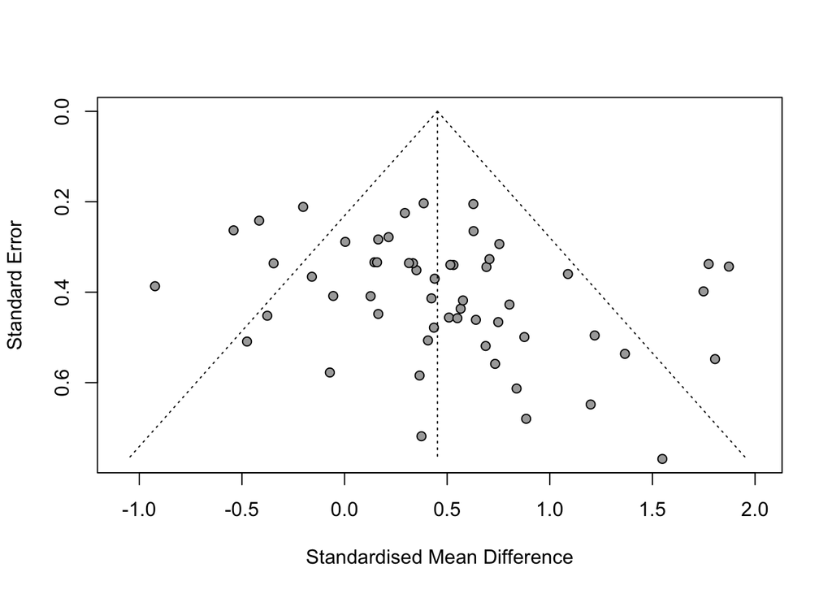

```r
funnel(ovsens.mod)
```

```r
metabias(ovsens.mod)
```

```
## Linear regression test of funnel plot asymmetry
##
## Test result: t = 2.25, df = 54, p-value = 0.0286
## Bias estimate: 1.5061 (SE = 0.6696)
##
## Details:
## - multiplicative residual heterogeneity variance (tau^2 = 2.3824)
## - predictor: standard error
## - weight:    inverse variance
## - reference: Egger et al. (1997), BMJ
```

Excluding D45 did not solve the problem.

#### (2) Baujat plot

The Baujat plot allows us to visually explore heterogeneity in our meta-analysis, visualizing the individual contribution of each case study on overall heterogeneity and the influence in the result.

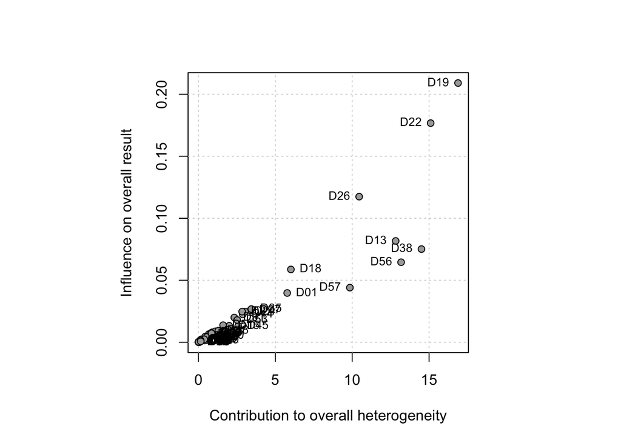

```r
baujat(overall.mod)
```

#### (3) Correlation

```r
cor.test(overall.mod$TE, overall.mod$seTE, method="kendall", continuity = TRUE, alternative = "two.sided")
```

```
##
##  Kendall's rank correlation tau
##
## data:  overall.mod$TE and overall.mod$seTE
## z = 3.1046, p-value = 0.001905
## alternative hypothesis: true tau is not equal to 0
## sample estimates:
##      tau
## 0.283208
```

Opps! we have a significant correlation in here.

#### (4) Trim & Fill

Duval & Twieedie’s approach ‘balances’ the model by *trimming* some case studies and *filling* others to balance the funnel plot (i.e., approaching to a symmetric model) and recalculates model estimates. If the meta-analysis is robust, we should not see any change in the direction and significance of the overall effect.

```r
trimfill(overall.mod)
```

```
## Number of studies: k = 72 (with 15 added studies)
## Number of observations: o = 2259 (o.e = 1123, o.c = 1136)
##
##                         SMD            95% CI    t p-value
## Random effects model 0.2262 [ 0.0409; 0.4114] 2.43  0.0174
## Prediction interval         [-1.0644; 1.5168]
##
## Quantifying heterogeneity (with 95% CIs):
##  tau^2 = 0.4106 [0.2653; 0.7143]; tau = 0.6408 [0.5150; 0.8452]
##  I^2 = 72.5% [65.3%; 78.3%]; H = 1.91 [1.70; 2.14]
##
## Test of heterogeneity:
##       Q d.f.  p-value
##  258.59   71 < 0.0001
##
## Details of meta-analysis methods:
## - Inverse variance method
## - Restricted maximum-likelihood estimator for tau^2
## - Q-Profile method for confidence interval of tau^2 and tau
## - Calculation of I^2 based on Q
## - Hartung-Knapp adjustment for random effects model (df = 71)
## - Prediction interval based on t-distribution (df = 71)
## - Trim-and-fill method to adjust for funnel plot asymmetry (L-estimator)
```

Well, well, well… it seems that our meta-analysis is robust and our results are reliable, despite the heterogeneity issues detected above. Now that we have checked it, we’ll examine our moderator variables to disentangle the complexity of these responses:

## Examining zone effect (tropical vs temperate)

```r
zone.mod<-update(overall.mod,
                      byvar = zone)
summary(zone.mod)
```

```
##         SMD             95% CI %W(random)      zone
## D01 -0.3457 [-1.0044;  0.3131]        2.0  tropical
## D02  0.6914 [ 0.0166;  1.3661]        2.0  tropical
## D03  0.1458 [-0.5085;  0.8000]        2.0  tropical
## D04  0.4355 [-0.5022;  1.3731]        1.5  tropical
## D05  0.5657 [-0.2899;  1.4213]        1.6  tropical
## D06  0.7060 [ 0.0652;  1.3467]        2.1  tropical
## D07 -0.4752 [-1.4731;  0.5227]        1.4 temperate
## D08  0.4065 [-0.5866;  1.3996]        1.4 temperate
## D09  0.2146 [-0.3307;  0.7599]        2.3  tropical
## D10  0.7336 [-0.3611;  1.8282]        1.3 temperate
## D11  0.1270 [-0.6741;  0.9281]        1.7 temperate
## D12  0.4391 [-0.2863;  1.1646]        1.9  tropical
## D13 -0.9234 [-1.6814; -0.1654]        1.8  tropical
## D14 -0.1591 [-0.8761;  0.5578]        1.9  tropical
## D15  1.5484 [ 0.0418;  3.0550]        0.8  tropical
## D16  0.8762 [-0.1021;  1.8544]        1.4  tropical
## D17  0.8850 [-0.4477;  2.2177]        1.0  tropical
## D18  1.8053 [ 0.7314;  2.8791]        1.3  tropical
## D19  1.8727 [ 1.1997;  2.5457]        2.0 temperate
## D20  0.7542 [ 0.1789;  1.3295]        2.2 temperate
## D21  0.1642 [-0.3912;  0.7195]        2.3 temperate
## D22  1.7740 [ 1.1122;  2.4358]        2.0 temperate
## D23  0.3502 [-0.3384;  1.0387]        2.0  tropical
## D24  1.0885 [ 0.3832;  1.7938]        1.9 temperate
## D25  0.5305 [-0.1355;  1.1965]        2.0 temperate
## D26  1.7491 [ 0.9687;  2.5294]        1.8  tropical
## D27  1.3660 [ 0.3149;  2.4172]        1.3  tropical
## D28  0.6875 [-0.3295;  1.7046]        1.4  tropical
## D29  0.6276 [ 0.2257;  1.0295]        2.6 temperate
## D30  0.7488 [-0.1647;  1.6623]        1.5 temperate
## D31  1.2187 [ 0.2473;  2.1902]        1.4 temperate
## D32  0.5088 [-0.3850;  1.4026]        1.6 temperate
## D33  0.5497 [-0.3469;  1.4464]        1.6 temperate
## D34  0.1643 [-0.7140;  1.0427]        1.6 temperate
## D35 -0.3764 [-1.2625;  0.5096]        1.6 temperate
## D36  0.8035 [-0.0340;  1.6411]        1.7 temperate
## D37  0.6286 [ 0.1094;  1.1478]        2.3  tropical
## D38 -0.5406 [-1.0564; -0.0248]        2.4  tropical
## D39  0.2939 [-0.1469;  0.7346]        2.5 temperate
```

[output cut: 36 more lines]

```
## zone = tropical   31 0.4169 [0.1953; 0.6384] 0.1803 0.4246 66.99 55.2%
## zone = temperate  26 0.5083 [0.2615; 0.7552] 0.2433 0.4933 75.55 66.9%
##
## Test for subgroup differences (random effects model):
##                   Q d.f. p-value
## Between groups 0.32    1  0.5717
##
## Details of meta-analysis methods:
## - Inverse variance method
## - Restricted maximum-likelihood estimator for tau^2
## - Q-Profile method for confidence interval of tau^2 and tau
## - Calculation of I^2 based on Q
## - Hartung-Knapp adjustment for random effects model (df = 56)
## - Prediction interval based on t-distribution (df = 56)
## - Hedges' g (bias corrected standardised mean difference; using exact formulae)
```

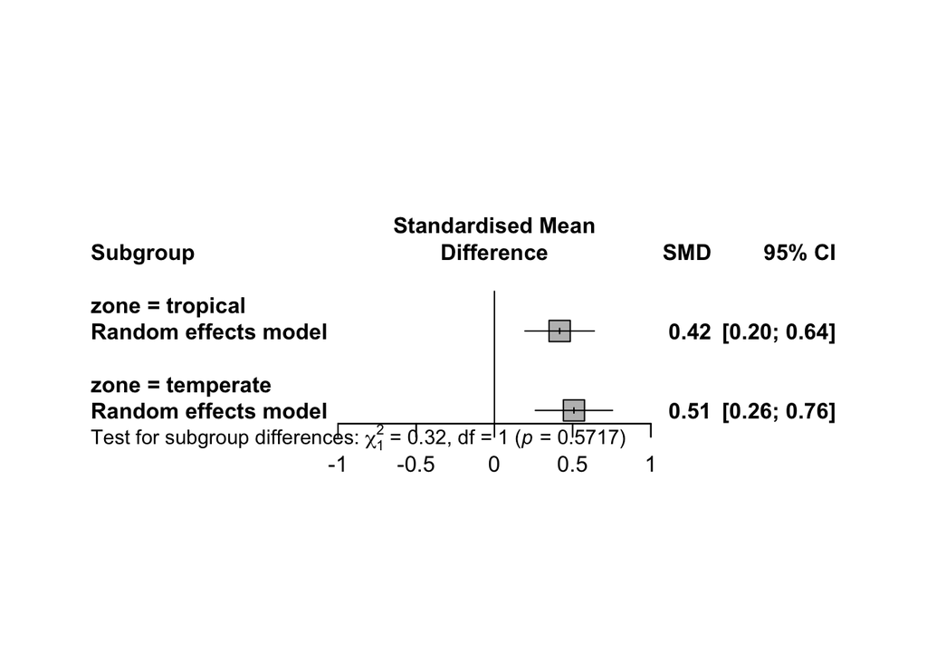

```r
forest(zone.mod,
            comb.random = TRUE,
            layout = "subgroup",
            overall = FALSE,
            prediction = FALSE,
            hetstat = FALSE,
            xlim=c(-1,1))
```

## Examining crop effects

```r
crop.mod<-update(overall.mod,
                      byvar = crop)
summary(crop.mod)
```

```
##         SMD             95% CI %W(random)       crop
## D01 -0.3457 [-1.0044;  0.3131]        2.0     coffee
## D02  0.6914 [ 0.0166;  1.3661]        2.0     coffee
## D03  0.1458 [-0.5085;  0.8000]        2.0     coffee
## D04  0.4355 [-0.5022;  1.3731]        1.5     coffee
## D05  0.5657 [-0.2899;  1.4213]        1.6     coffee
## D06  0.7060 [ 0.0652;  1.3467]        2.1      cacao
## D07 -0.4752 [-1.4731;  0.5227]        1.4    cereals
## D08  0.4065 [-0.5866;  1.3996]        1.4    cereals
## D09  0.2146 [-0.3307;  0.7599]        2.3       raps
## D10  0.7336 [-0.3611;  1.8282]        1.3      apple
## D11  0.1270 [-0.6741;  0.9281]        1.7      apple
## D12  0.4391 [-0.2863;  1.1646]        1.9      cacao
## D13 -0.9234 [-1.6814; -0.1654]        1.8      cacao
## D14 -0.1591 [-0.8761;  0.5578]        1.9      cacao
## D15  1.5484 [ 0.0418;  3.0550]        0.8     coffee
## D16  0.8762 [-0.1021;  1.8544]        1.4     coffee
## D17  0.8850 [-0.4477;  2.2177]        1.0     coffee
## D18  1.8053 [ 0.7314;  2.8791]        1.3     coffee
## D19  1.8727 [ 1.1997;  2.5457]        2.0   vineyard
## D20  0.7542 [ 0.1789;  1.3295]        2.2   vineyard
## D21  0.1642 [-0.3912;  0.7195]        2.3   vineyard
## D22  1.7740 [ 1.1122;  2.4358]        2.0   vineyard
## D23  0.3502 [-0.3384;  1.0387]        2.0  macadamia
## D24  1.0885 [ 0.3832;  1.7938]        1.9   brassica
## D25  0.5305 [-0.1355;  1.1965]        2.0 strawberry
## D26  1.7491 [ 0.9687;  2.5294]        1.8   brassica
## D27  1.3660 [ 0.3149;  2.4172]        1.3   brassica
## D28  0.6875 [-0.3295;  1.7046]        1.4       palm
## D29  0.6276 [ 0.2257;  1.0295]        2.6      apple
## D30  0.7488 [-0.1647;  1.6623]        1.5      apple
## D31  1.2187 [ 0.2473;  2.1902]        1.4      apple
## D32  0.5088 [-0.3850;  1.4026]        1.6      apple
## D33  0.5497 [-0.3469;  1.4464]        1.6      apple
## D34  0.1643 [-0.7140;  1.0427]        1.6      apple
## D35 -0.3764 [-1.2625;  0.5096]        1.6      apple
## D36  0.8035 [-0.0340;  1.6411]        1.7   vineyard
## D37  0.6286 [ 0.1094;  1.1478]        2.3     coffee
## D38 -0.5406 [-1.0564; -0.0248]        2.4     coffee
## D39  0.2939 [-0.1469;  0.7346]        2.5      apple
```

[output cut: 44 more lines]

```
## crop = strawberry   2 0.1161 [-4.4946; 4.7267] 0.1879 0.4335  3.35 70.1%
## crop = palm         1 0.6875 [-0.3295; 1.7046]     --     --  0.00    --
##
## Test for subgroup differences (random effects model):
##                    Q d.f. p-value
## Between groups 29.00    9  0.0006
##
## Details of meta-analysis methods:
## - Inverse variance method
## - Restricted maximum-likelihood estimator for tau^2
## - Q-Profile method for confidence interval of tau^2 and tau
## - Calculation of I^2 based on Q
## - Hartung-Knapp adjustment for random effects model (df = 56)
## - Prediction interval based on t-distribution (df = 56)
## - Hedges' g (bias corrected standardised mean difference; using exact formulae)
```

[figure not shown]

```r
forest(crop.mod,
            comb.random = TRUE,
            layout = "subgroup",
            overall = FALSE,
            prediction = FALSE,
            hetstat = FALSE,
            xlim=c(-1,2.5))
```

#### Excluding levels with N < 4:

```r
sel<-crop.mod$bylevs[crop.mod$k.w > 3]

crop2.mod<-update(overall.mod,
                      subset = crop %in% sel,
                      byvar = crop)
summary(crop2.mod)
```

```
##         SMD             95% CI %W(random)     crop
## D01 -0.3457 [-1.0044;  0.3131]        2.4   coffee
## D02  0.6914 [ 0.0166;  1.3661]        2.4   coffee
## D03  0.1458 [-0.5085;  0.8000]        2.4   coffee
## D04  0.4355 [-0.5022;  1.3731]        1.8   coffee
## D05  0.5657 [-0.2899;  1.4213]        1.9   coffee
## D06  0.7060 [ 0.0652;  1.3467]        2.5    cacao
## D07 -0.4752 [-1.4731;  0.5227]        1.6  cereals
## D08  0.4065 [-0.5866;  1.3996]        1.6  cereals
## D10  0.7336 [-0.3611;  1.8282]        1.5    apple
## D11  0.1270 [-0.6741;  0.9281]        2.1    apple
## D12  0.4391 [-0.2863;  1.1646]        2.2    cacao
## D13 -0.9234 [-1.6814; -0.1654]        2.2    cacao
## D14 -0.1591 [-0.8761;  0.5578]        2.3    cacao
## D15  1.5484 [ 0.0418;  3.0550]        0.9   coffee
## D16  0.8762 [-0.1021;  1.8544]        1.7   coffee
## D17  0.8850 [-0.4477;  2.2177]        1.1   coffee
## D18  1.8053 [ 0.7314;  2.8791]        1.5   coffee
## D19  1.8727 [ 1.1997;  2.5457]        2.4 vineyard
## D20  0.7542 [ 0.1789;  1.3295]        2.6 vineyard
## D21  0.1642 [-0.3912;  0.7195]        2.7 vineyard
## D22  1.7740 [ 1.1122;  2.4358]        2.4 vineyard
## D29  0.6276 [ 0.2257;  1.0295]        3.1    apple
## D30  0.7488 [-0.1647;  1.6623]        1.8    apple
## D31  1.2187 [ 0.2473;  2.1902]        1.7    apple
## D32  0.5088 [-0.3850;  1.4026]        1.8    apple
## D33  0.5497 [-0.3469;  1.4464]        1.8    apple
## D34  0.1643 [-0.7140;  1.0427]        1.9    apple
## D35 -0.3764 [-1.2625;  0.5096]        1.9    apple
## D36  0.8035 [-0.0340;  1.6411]        2.0 vineyard
## D37  0.6286 [ 0.1094;  1.1478]        2.8   coffee
## D38 -0.5406 [-1.0564; -0.0248]        2.8   coffee
## D39  0.2939 [-0.1469;  0.7346]        3.0    apple
## D40  0.3334 [-0.3249;  0.9918]        2.4   coffee
## D41  0.1584 [-0.4960;  0.8129]        2.4   coffee
## D42  0.3141 [-0.3437;  0.9719]        2.4   coffee
## D43  0.5157 [-0.1497;  1.1810]        2.4   coffee
## D44  0.3747 [-1.0337;  1.7831]        1.0   coffee
## D45  2.0685 [ 0.1104;  4.0267]        0.6   coffee
## D46  0.3656 [-0.7797;  1.5108]        1.4  cereals
```

[output cut: 31 more lines]

```
## crop = apple     12 0.3287 [ 0.0467; 0.6107] 0.0840 0.2899 19.46 43.5%
## crop = vineyard   5 1.0634 [ 0.1475; 1.9794] 0.4431 0.6656 21.33 81.2%
##
## Test for subgroup differences (random effects model):
##                   Q d.f. p-value
## Between groups 6.22    4  0.1836
##
## Details of meta-analysis methods:
## - Inverse variance method
## - Restricted maximum-likelihood estimator for tau^2
## - Q-Profile method for confidence interval of tau^2 and tau
## - Calculation of I^2 based on Q
## - Hartung-Knapp adjustment for random effects model (df = 48)
## - Prediction interval based on t-distribution (df = 48)
## - Hedges' g (bias corrected standardised mean difference; using exact formulae)
```

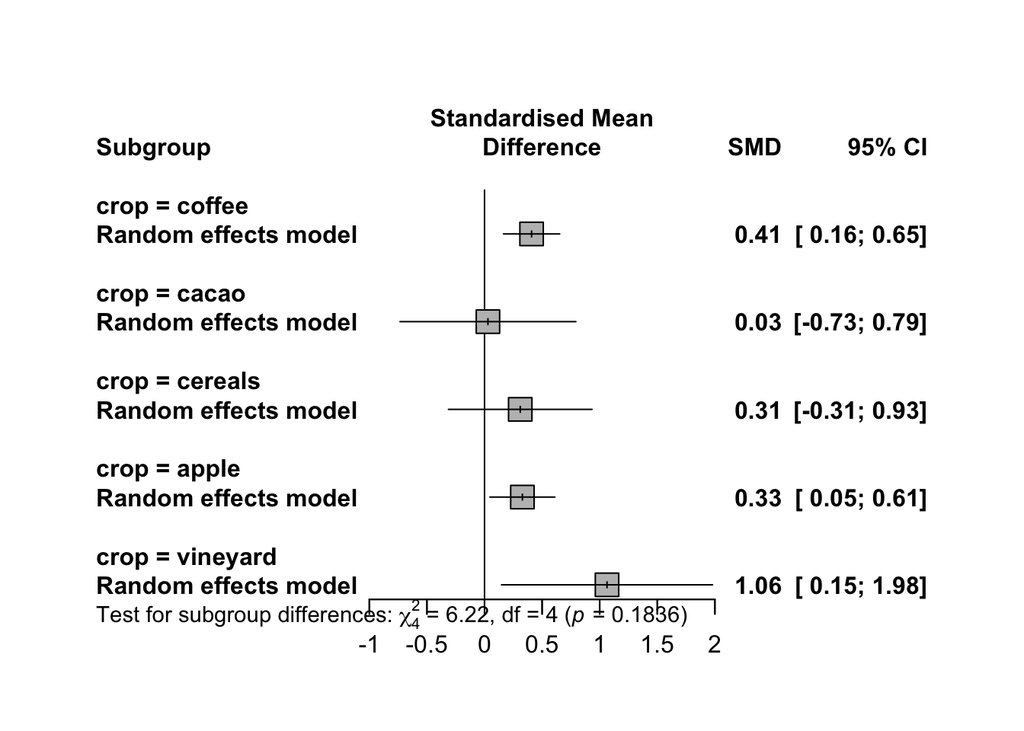

```r
forest(crop2.mod,
            comb.random = TRUE,
            layout = "subgroup",
            overall = FALSE,
            prediction = FALSE,
            hetstat = FALSE,
            xlim=c(-1,2))
```

## Examining experiment effects

```r
exp.mod<-update(overall.mod,
                      byvar = experiment)
summary(exp.mod)
```

```
##         SMD             95% CI %W(random) experiment
## D01 -0.3457 [-1.0044;  0.3131]        2.0  exclusion
## D02  0.6914 [ 0.0166;  1.3661]        2.0  exclusion
## D03  0.1458 [-0.5085;  0.8000]        2.0  exclusion
## D04  0.4355 [-0.5022;  1.3731]        1.5  exclusion
## D05  0.5657 [-0.2899;  1.4213]        1.6  exclusion
## D06  0.7060 [ 0.0652;  1.3467]        2.1  exclusion
## D07 -0.4752 [-1.4731;  0.5227]        1.4  exclusion
## D08  0.4065 [-0.5866;  1.3996]        1.4  exclusion
## D09  0.2146 [-0.3307;  0.7599]        2.3  exclusion
## D10  0.7336 [-0.3611;  1.8282]        1.3 attraction
## D11  0.1270 [-0.6741;  0.9281]        1.7 attraction
## D12  0.4391 [-0.2863;  1.1646]        1.9  exclusion
## D13 -0.9234 [-1.6814; -0.1654]        1.8  exclusion
## D14 -0.1591 [-0.8761;  0.5578]        1.9  exclusion
## D15  1.5484 [ 0.0418;  3.0550]        0.8  exclusion
## D16  0.8762 [-0.1021;  1.8544]        1.4  exclusion
## D17  0.8850 [-0.4477;  2.2177]        1.0  exclusion
## D18  1.8053 [ 0.7314;  2.8791]        1.3  exclusion
## D19  1.8727 [ 1.1997;  2.5457]        2.0 attraction
## D20  0.7542 [ 0.1789;  1.3295]        2.2 attraction
## D21  0.1642 [-0.3912;  0.7195]        2.3 attraction
## D22  1.7740 [ 1.1122;  2.4358]        2.0 attraction
## D23  0.3502 [-0.3384;  1.0387]        2.0  exclusion
## D24  1.0885 [ 0.3832;  1.7938]        1.9  exclusion
## D25  0.5305 [-0.1355;  1.1965]        2.0  exclusion
## D26  1.7491 [ 0.9687;  2.5294]        1.8  exclusion
## D27  1.3660 [ 0.3149;  2.4172]        1.3  exclusion
## D28  0.6875 [-0.3295;  1.7046]        1.4  exclusion
## D29  0.6276 [ 0.2257;  1.0295]        2.6  exclusion
## D30  0.7488 [-0.1647;  1.6623]        1.5  exclusion
## D31  1.2187 [ 0.2473;  2.1902]        1.4  exclusion
## D32  0.5088 [-0.3850;  1.4026]        1.6  exclusion
## D33  0.5497 [-0.3469;  1.4464]        1.6  exclusion
## D34  0.1643 [-0.7140;  1.0427]        1.6  exclusion
## D35 -0.3764 [-1.2625;  0.5096]        1.6  exclusion
## D36  0.8035 [-0.0340;  1.6411]        1.7 attraction
## D37  0.6286 [ 0.1094;  1.1478]        2.3  exclusion
## D38 -0.5406 [-1.0564; -0.0248]        2.4  exclusion
## D39  0.2939 [-0.1469;  0.7346]        2.5  exclusion
```

[output cut: 36 more lines]

```
## experiment = exclusion   50 0.3829 [0.2239; 0.5418] 0.1451 0.3809 102.32 52.1%
## experiment = attraction   7 0.8989 [0.2409; 1.5568] 0.3894 0.6240  25.42 76.4%
##
## Test for subgroup differences (random effects model):
##                   Q d.f. p-value
## Between groups 3.39    1  0.0656
##
## Details of meta-analysis methods:
## - Inverse variance method
## - Restricted maximum-likelihood estimator for tau^2
## - Q-Profile method for confidence interval of tau^2 and tau
## - Calculation of I^2 based on Q
## - Hartung-Knapp adjustment for random effects model (df = 56)
## - Prediction interval based on t-distribution (df = 56)
## - Hedges' g (bias corrected standardised mean difference; using exact formulae)
```

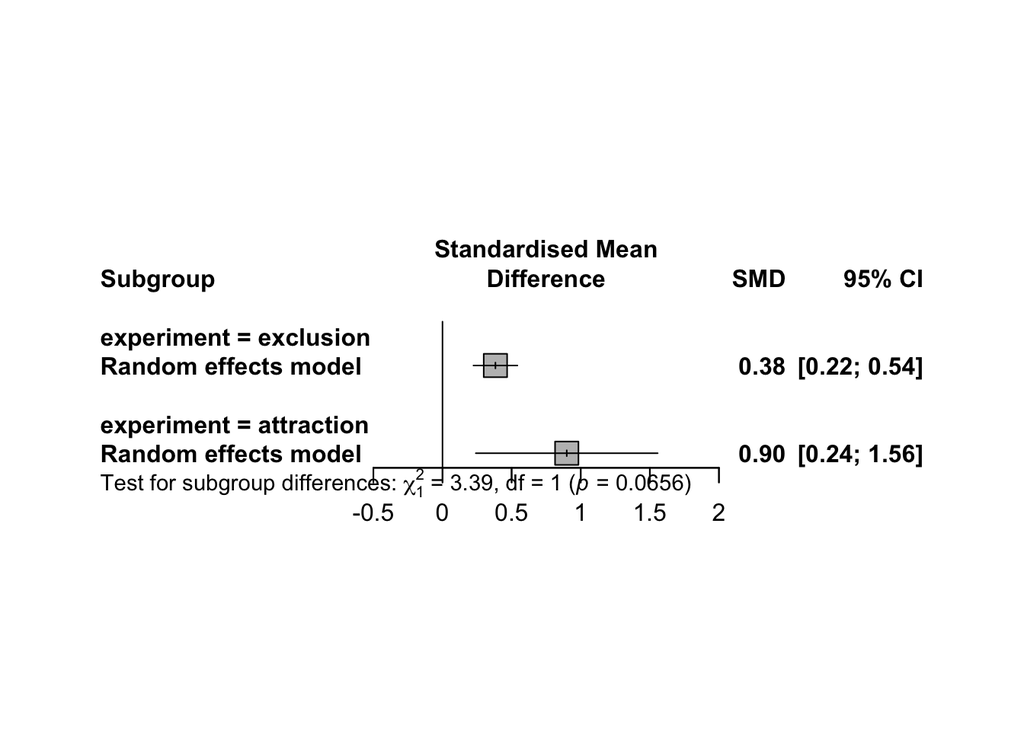

```r
forest(exp.mod,
            comb.random = TRUE,
            layout = "subgroup",
            overall = FALSE,
            prediction = FALSE,
            hetstat = FALSE,
            xlim=c(-0.5,2))
```

## Examining agriculture effects

```r
agric.mod<-update(overall.mod,
                      byvar = agriculture)
summary(agric.mod)
```

```
##         SMD             95% CI %W(random)  agriculture
## D01 -0.3457 [-1.0044;  0.3131]        2.0 agroforestry
## D02  0.6914 [ 0.0166;  1.3661]        2.0 agroforestry
## D03  0.1458 [-0.5085;  0.8000]        2.0 agroforestry
## D04  0.4355 [-0.5022;  1.3731]        1.5 agroforestry
## D05  0.5657 [-0.2899;  1.4213]        1.6  traditional
## D06  0.7060 [ 0.0652;  1.3467]        2.1  traditional
## D07 -0.4752 [-1.4731;  0.5227]        1.4  traditional
## D08  0.4065 [-0.5866;  1.3996]        1.4  traditional
## D09  0.2146 [-0.3307;  0.7599]        2.3  traditional
## D10  0.7336 [-0.3611;  1.8282]        1.3  traditional
## D11  0.1270 [-0.6741;  0.9281]        1.7      organic
## D12  0.4391 [-0.2863;  1.1646]        1.9  traditional
## D13 -0.9234 [-1.6814; -0.1654]        1.8  traditional
## D14 -0.1591 [-0.8761;  0.5578]        1.9  traditional
## D15  1.5484 [ 0.0418;  3.0550]        0.8        mixed
## D16  0.8762 [-0.1021;  1.8544]        1.4        mixed
## D17  0.8850 [-0.4477;  2.2177]        1.0        mixed
## D18  1.8053 [ 0.7314;  2.8791]        1.3        mixed
## D19  1.8727 [ 1.1997;  2.5457]        2.0  traditional
## D20  0.7542 [ 0.1789;  1.3295]        2.2  traditional
## D21  0.1642 [-0.3912;  0.7195]        2.3  traditional
## D22  1.7740 [ 1.1122;  2.4358]        2.0  traditional
## D23  0.3502 [-0.3384;  1.0387]        2.0  traditional
## D24  1.0885 [ 0.3832;  1.7938]        1.9  traditional
## D25  0.5305 [-0.1355;  1.1965]        2.0      organic
## D26  1.7491 [ 0.9687;  2.5294]        1.8  traditional
## D27  1.3660 [ 0.3149;  2.4172]        1.3  traditional
## D28  0.6875 [-0.3295;  1.7046]        1.4  traditional
## D29  0.6276 [ 0.2257;  1.0295]        2.6      organic
## D30  0.7488 [-0.1647;  1.6623]        1.5        mixed
## D31  1.2187 [ 0.2473;  2.1902]        1.4        mixed
## D32  0.5088 [-0.3850;  1.4026]        1.6        mixed
## D33  0.5497 [-0.3469;  1.4464]        1.6        mixed
## D34  0.1643 [-0.7140;  1.0427]        1.6        mixed
## D35 -0.3764 [-1.2625;  0.5096]        1.6        mixed
## D36  0.8035 [-0.0340;  1.6411]        1.7  traditional
## D37  0.6286 [ 0.1094;  1.1478]        2.3  traditional
## D38 -0.5406 [-1.0564; -0.0248]        2.4  traditional
## D39  0.2939 [-0.1469;  0.7346]        2.5  traditional
```

[output cut: 43 more lines]

```
## agriculture = organic      73.0%
## agriculture = mixed        35.5%
##
## Test for subgroup differences (random effects model):
##                   Q d.f. p-value
## Between groups 5.04    3  0.1686
##
## Details of meta-analysis methods:
## - Inverse variance method
## - Restricted maximum-likelihood estimator for tau^2
## - Q-Profile method for confidence interval of tau^2 and tau
## - Calculation of I^2 based on Q
## - Hartung-Knapp adjustment for random effects model (df = 56)
## - Prediction interval based on t-distribution (df = 56)
## - Hedges' g (bias corrected standardised mean difference; using exact formulae)
```

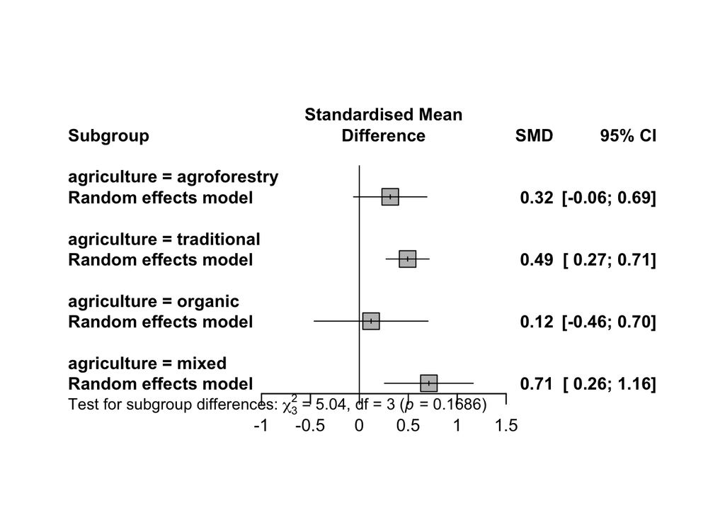

```r
forest(agric.mod,
            comb.random = TRUE,
            layout = "subgroup",
            overall = FALSE,
            prediction = FALSE,
            hetstat = FALSE,
            xlim=c(-1,1.5))
```

## Examining pest effects

```r
pest.mod<-update(overall.mod,
                      byvar = pest)
summary(pest.mod)
```

```
##         SMD             95% CI %W(random)      pest
## D01 -0.3457 [-1.0044;  0.3131]        2.0 arthropod
## D02  0.6914 [ 0.0166;  1.3661]        2.0 arthropod
## D03  0.1458 [-0.5085;  0.8000]        2.0 arthropod
## D04  0.4355 [-0.5022;  1.3731]        1.5 arthropod
## D05  0.5657 [-0.2899;  1.4213]        1.6 arthropod
## D06  0.7060 [ 0.0652;  1.3467]        2.1 arthropod
## D07 -0.4752 [-1.4731;  0.5227]        1.4 arthropod
## D08  0.4065 [-0.5866;  1.3996]        1.4 arthropod
## D09  0.2146 [-0.3307;  0.7599]        2.3 arthropod
## D10  0.7336 [-0.3611;  1.8282]        1.3 arthropod
## D11  0.1270 [-0.6741;  0.9281]        1.7 arthropod
## D12  0.4391 [-0.2863;  1.1646]        1.9 arthropod
## D13 -0.9234 [-1.6814; -0.1654]        1.8 arthropod
## D14 -0.1591 [-0.8761;  0.5578]        1.9 arthropod
## D15  1.5484 [ 0.0418;  3.0550]        0.8 arthropod
## D16  0.8762 [-0.1021;  1.8544]        1.4 arthropod
## D17  0.8850 [-0.4477;  2.2177]        1.0 arthropod
## D18  1.8053 [ 0.7314;  2.8791]        1.3 arthropod
## D19  1.8727 [ 1.1997;  2.5457]        2.0      bird
## D20  0.7542 [ 0.1789;  1.3295]        2.2      bird
## D21  0.1642 [-0.3912;  0.7195]        2.3      bird
## D22  1.7740 [ 1.1122;  2.4358]        2.0      bird
## D23  0.3502 [-0.3384;  1.0387]        2.0 arthropod
## D24  1.0885 [ 0.3832;  1.7938]        1.9 arthropod
## D25  0.5305 [-0.1355;  1.1965]        2.0      bird
## D26  1.7491 [ 0.9687;  2.5294]        1.8 arthropod
## D27  1.3660 [ 0.3149;  2.4172]        1.3 arthropod
## D28  0.6875 [-0.3295;  1.7046]        1.4 arthropod
## D29  0.6276 [ 0.2257;  1.0295]        2.6 arthropod
## D30  0.7488 [-0.1647;  1.6623]        1.5 arthropod
## D31  1.2187 [ 0.2473;  2.1902]        1.4 arthropod
## D32  0.5088 [-0.3850;  1.4026]        1.6 arthropod
## D33  0.5497 [-0.3469;  1.4464]        1.6 arthropod
## D34  0.1643 [-0.7140;  1.0427]        1.6 arthropod
## D35 -0.3764 [-1.2625;  0.5096]        1.6 arthropod
## D36  0.8035 [-0.0340;  1.6411]        1.7      bird
## D37  0.6286 [ 0.1094;  1.1478]        2.3 arthropod
## D38 -0.5406 [-1.0564; -0.0248]        2.4 arthropod
## D39  0.2939 [-0.1469;  0.7346]        2.5 arthropod
```

[output cut: 36 more lines]

```
## pest = arthropod  51 0.3787 [0.2216; 0.5358] 0.1434 0.3787 102.70 51.3%
## pest = bird        6 0.9736 [0.2438; 1.7034] 0.3789 0.6156  22.91 78.2%
##
## Test for subgroup differences (random effects model):
##                   Q d.f. p-value
## Between groups 4.08    1  0.0434
##
## Details of meta-analysis methods:
## - Inverse variance method
## - Restricted maximum-likelihood estimator for tau^2
## - Q-Profile method for confidence interval of tau^2 and tau
## - Calculation of I^2 based on Q
## - Hartung-Knapp adjustment for random effects model (df = 56)
## - Prediction interval based on t-distribution (df = 56)
## - Hedges' g (bias corrected standardised mean difference; using exact formulae)
```

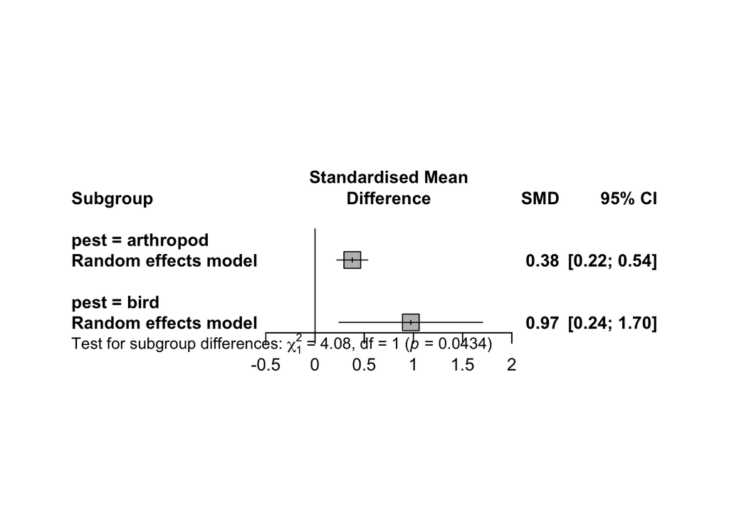

```r
forest(pest.mod,
            comb.random = TRUE,
            layout = "subgroup",
            overall = FALSE,
            prediction = FALSE,
            hetstat = FALSE,
            xlim=c(-0.5,2))
```

## Further reading

Wanna explore more about meta-analysis? Check Mathias Harrer’s guide: https://doing-meta.guide

Licensing Creative Commons License

Licensed under a Creative Commons Attribution-ShareAlike 4.0 International License.  
2026 - Francisco E. Fontúrbel